# Eric_Hirsch_624_Homework_6

2023-3-12

## Results

### 9.1

*9.1 Figure 9.32 shows the ACFs for 36 random numbers, 360 random numbers and 1,000 random numbers.*

*9.1a Explain the differences among these figures. Do they all indicate that the data are white noise?*

Yes, there is no patterning and no correlations exceed .05.

*9.1b Why are the critical values at different distances from the mean of zero? Why are the autocorrelations different in each figure when they each refer to white noise?.*

They are constructed from different sample sizes. The larger the sample, the more “white noise” the sample will be.

### 9.2

*9.2 A classic example of a non-stationary series are stock prices. Plot the daily closing prices for Amazon stock (contained in gafa_stock), along with the ACF and PACF. Explain how each plot shows that the series is non-stationary and should be differenced.*

The plot of the time series shows a clear trend upward. The ACF shows an extreme level of autocorrelation. The PACF shows the extreme degree to which each observation is correlated with the previous one.

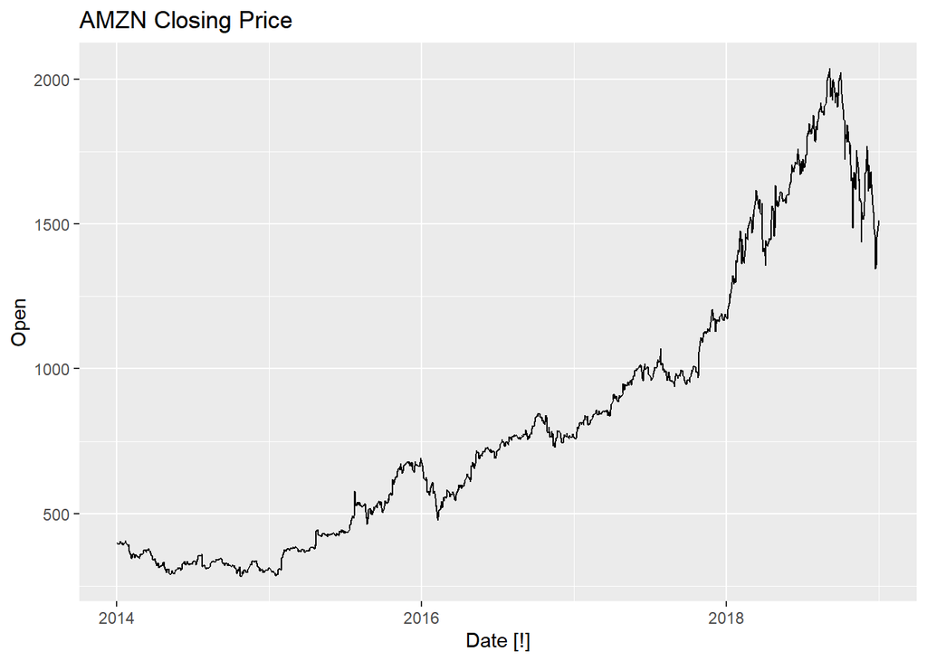

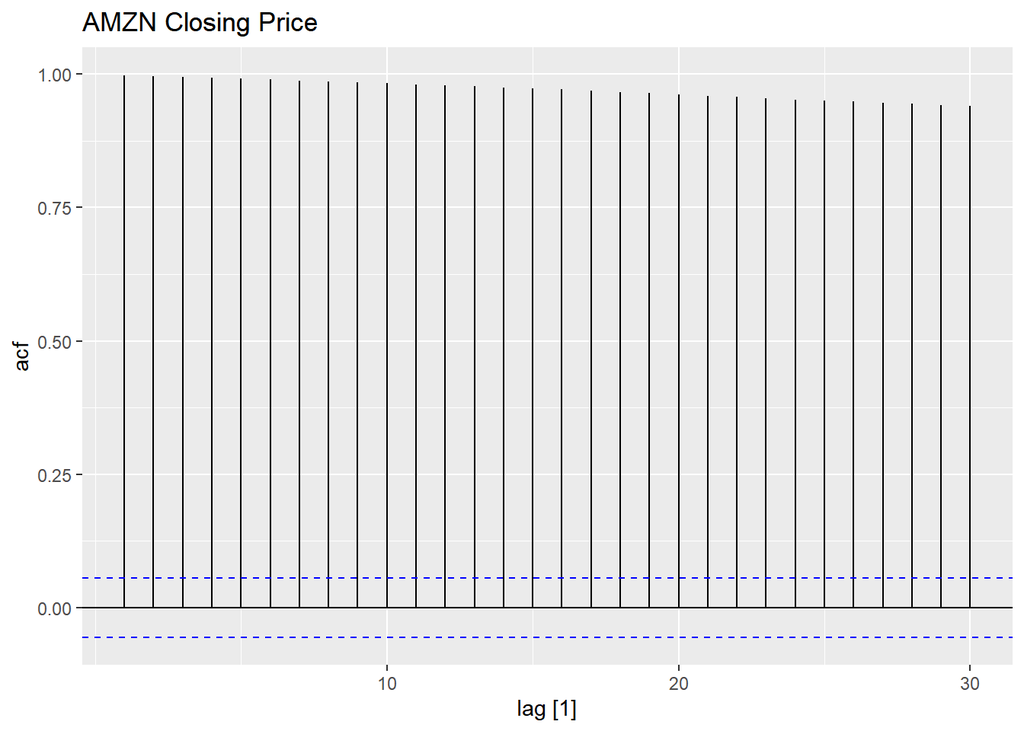

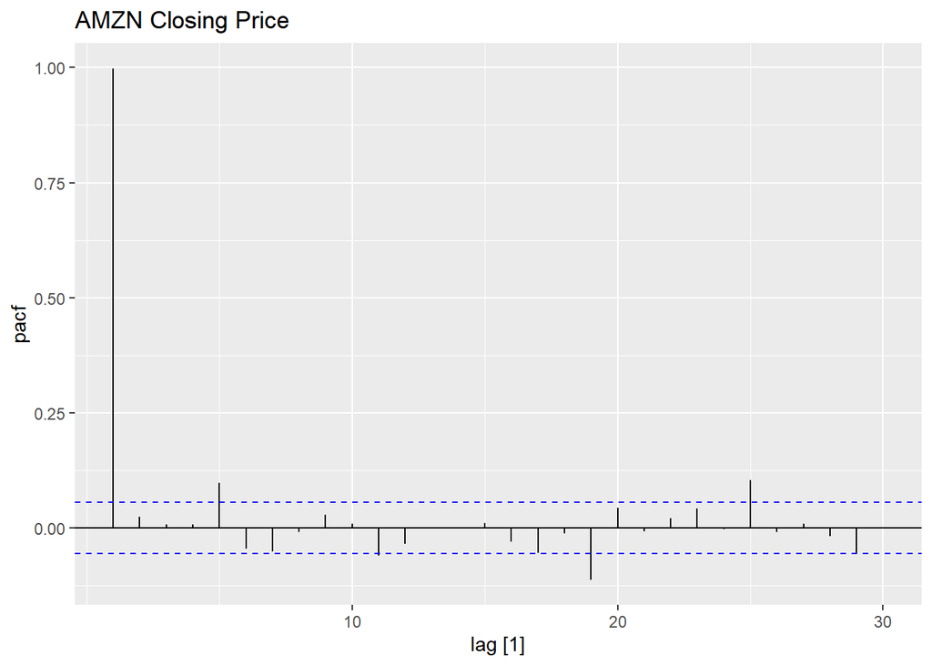

### 9.3

*9.3 For the following series, find an appropriate Box-Cox transformation and order of differencing in order to obtain stationary data.*

*9.3a Turkish GDP from global_economy.*

The boxcox transformation is not necessary to smooth the variance, but does make the curve more linear. One difference is all that is necessary to create a stationary series.

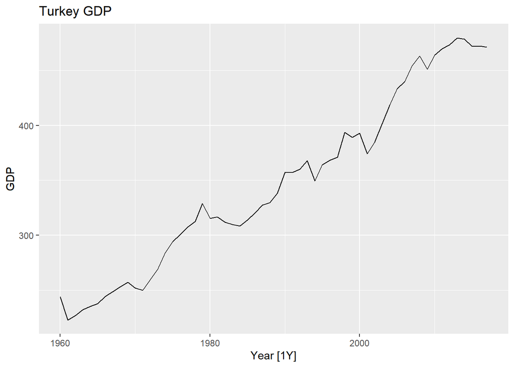

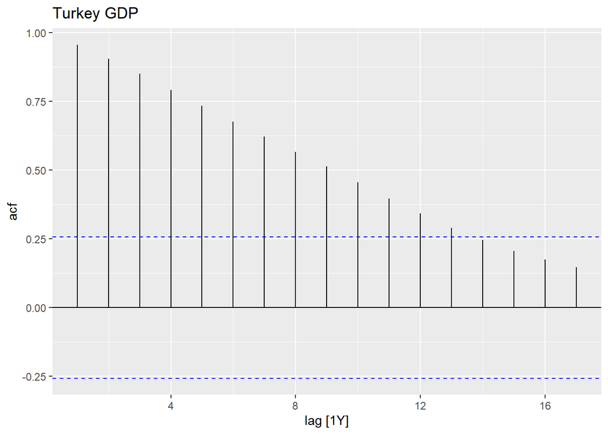

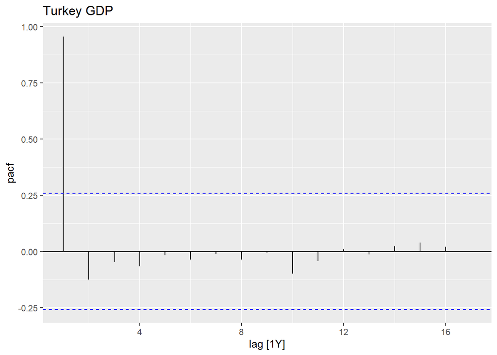

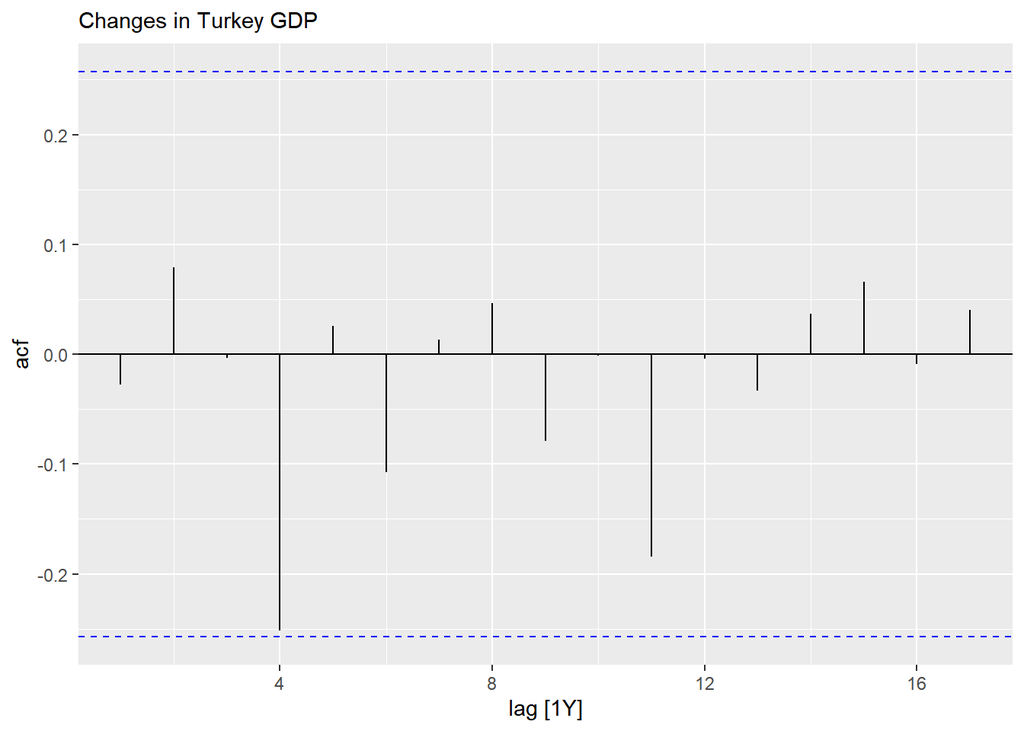

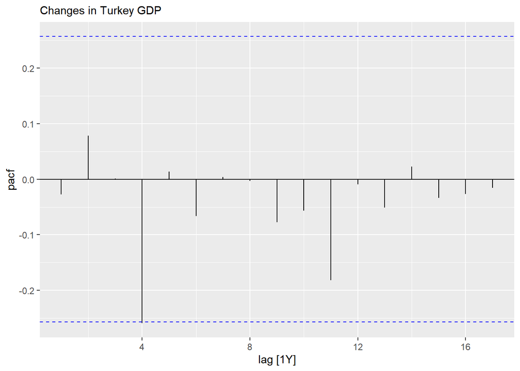

```
## # A tibble: 1 × 3
##   Country lb_stat lb_pvalue
##   <fct>     <dbl>     <dbl>
## 1 Turkey     5.84     0.829
```

*9.3b Accommodation takings in the state of Tasmania from aus_accommodation.*

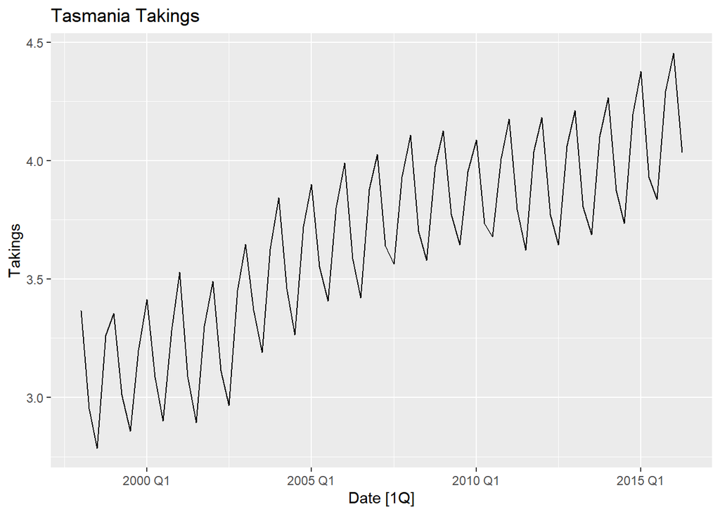

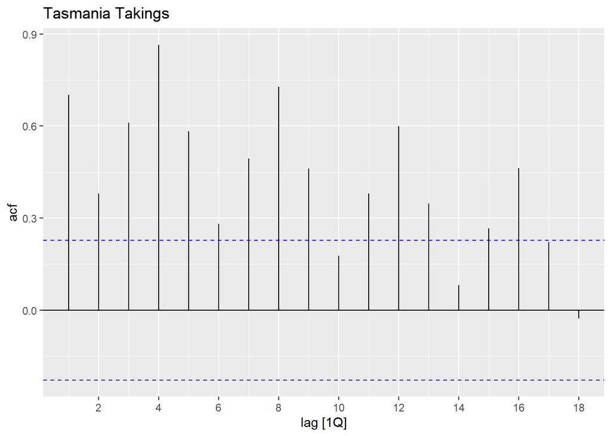

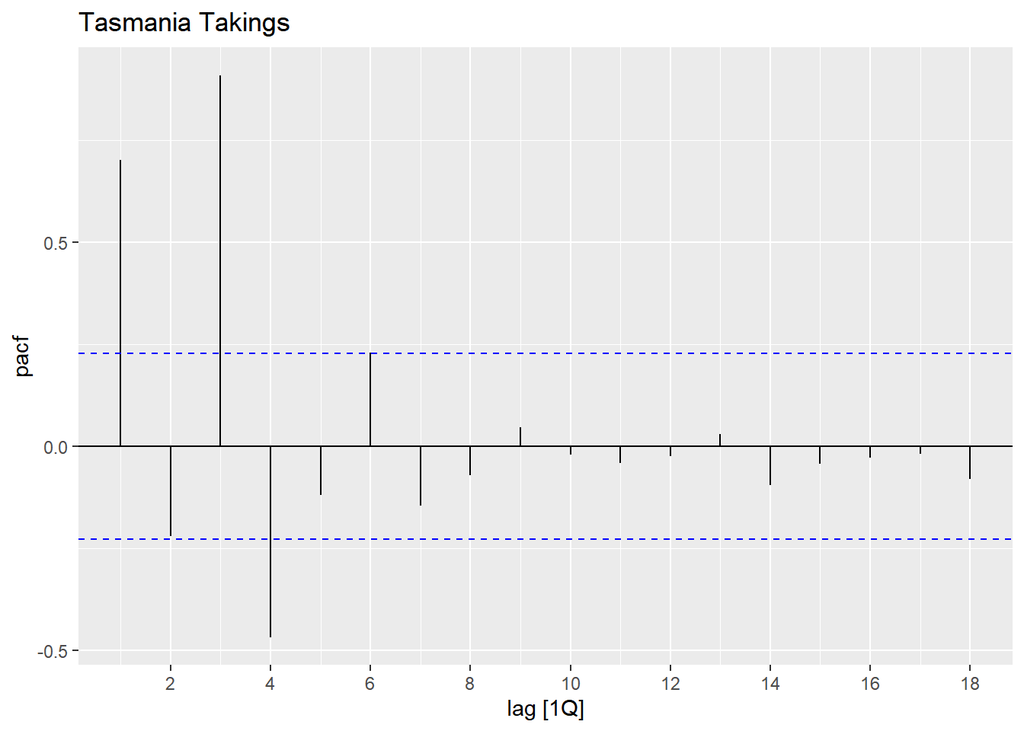

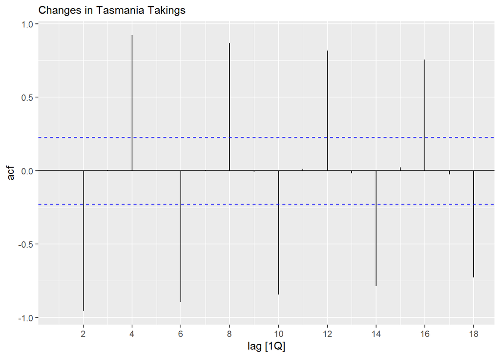

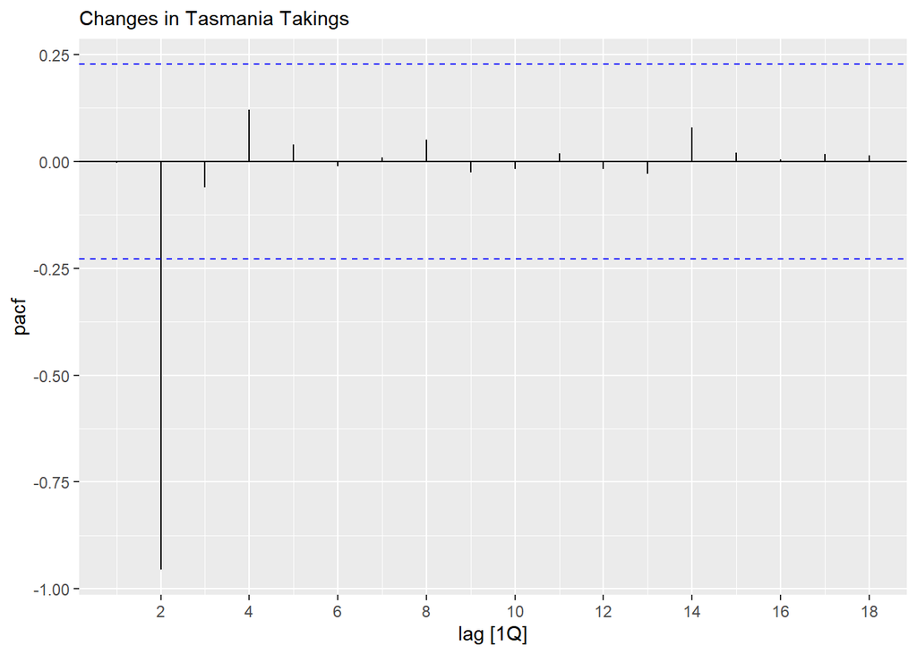

```
## # A tibble: 1 × 3
##   State    lb_stat lb_pvalue
##   <chr>      <dbl>     <dbl>
## 1 Tasmania    328.         0
```

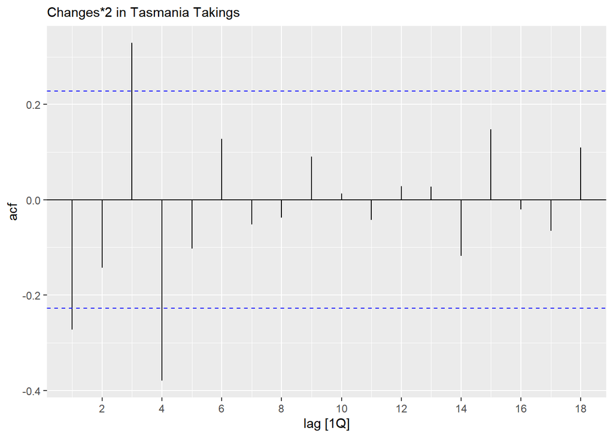

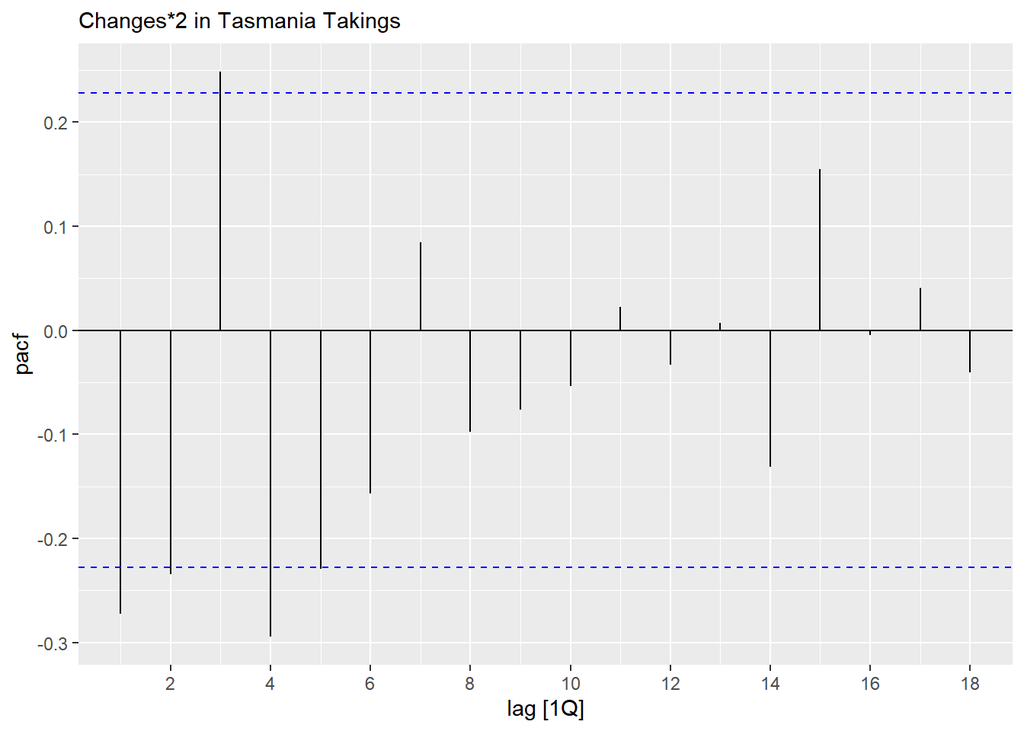

```
## # A tibble: 1 × 3
##   State    lb_stat lb_pvalue
##   <chr>      <dbl>     <dbl>
## 1 Tasmania    28.8   0.00132
```

*9.3c Monthly sales from souvenirs.*

Again, two differences are needed, including a yearly lag.

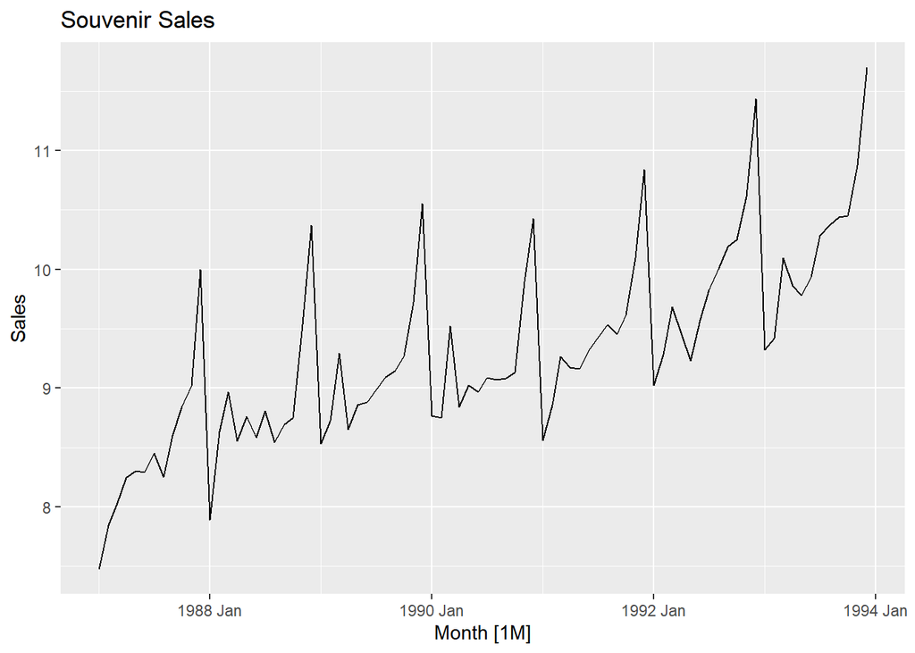

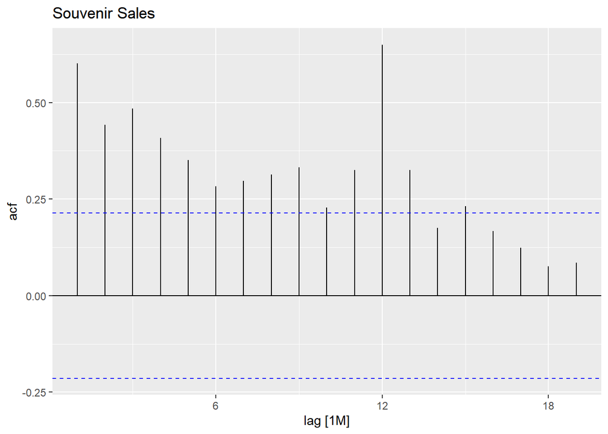

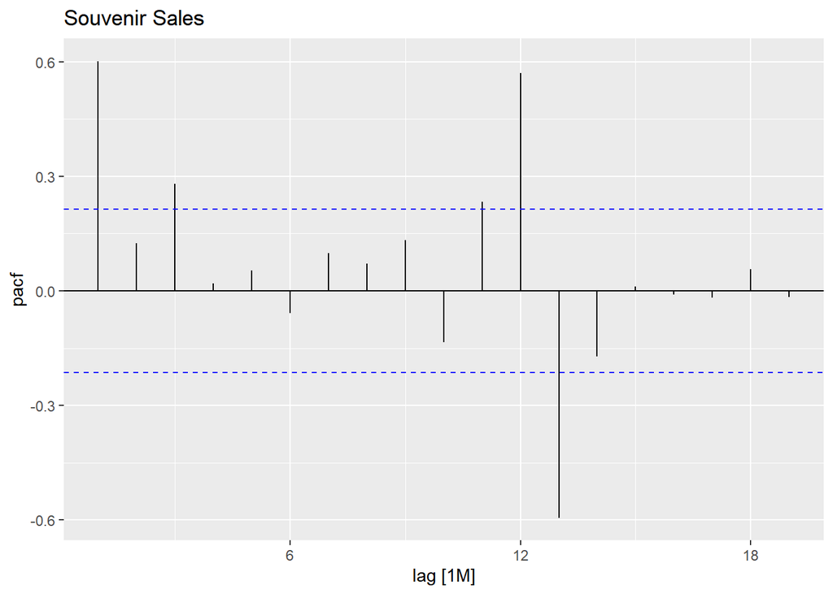

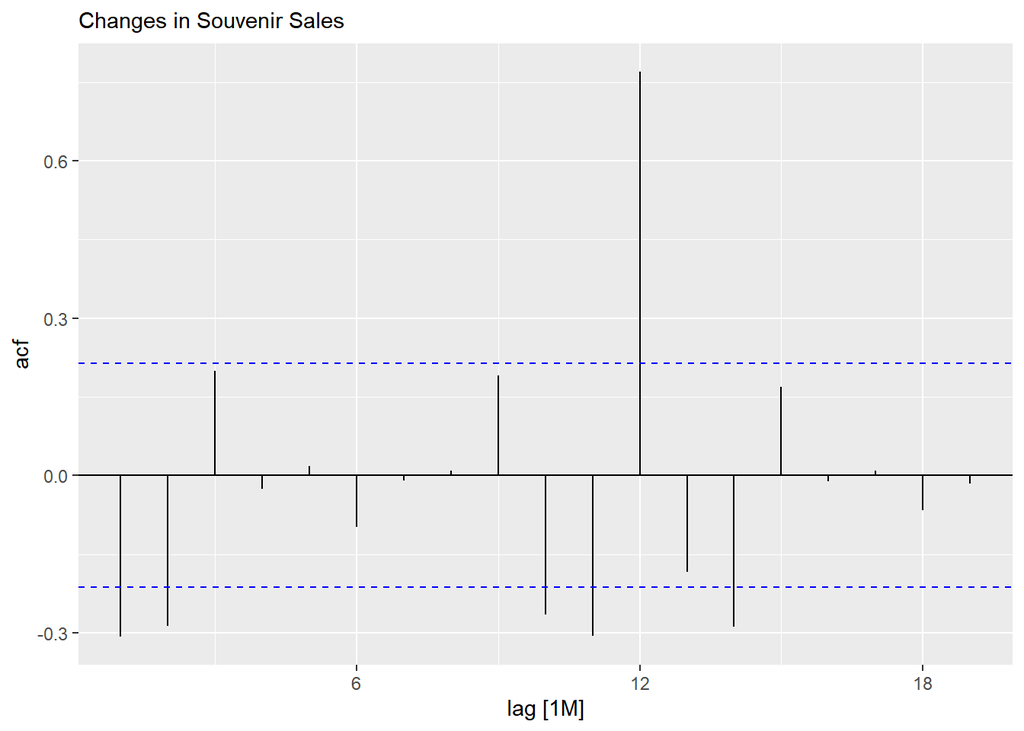

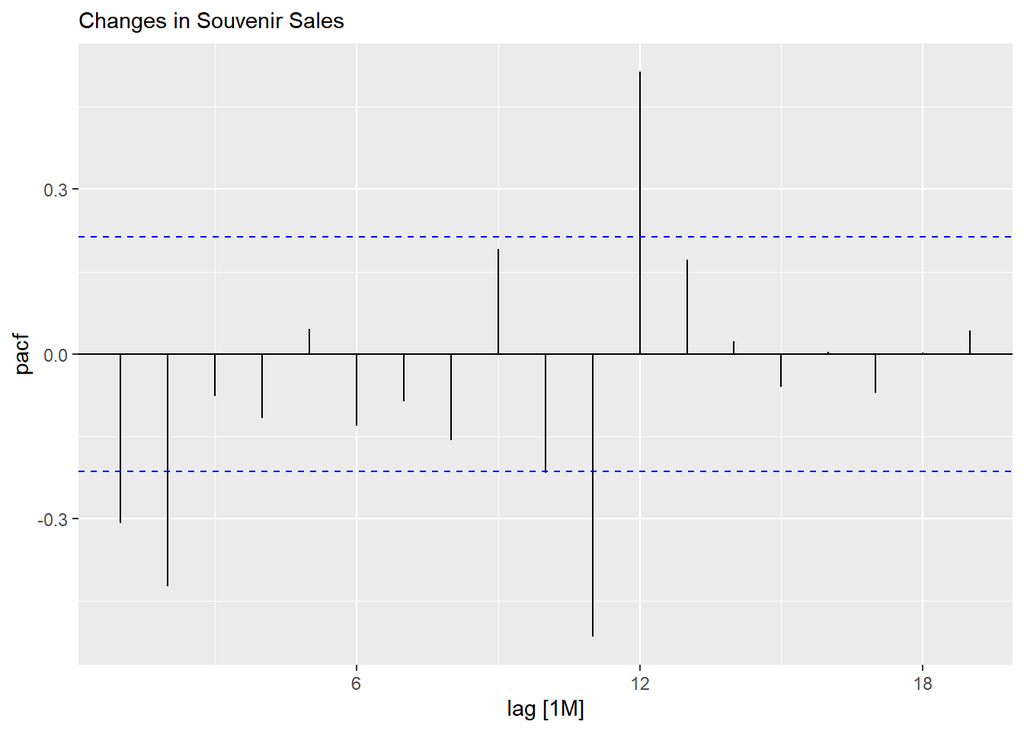

```
## # A tibble: 1 × 2
##   lb_stat lb_pvalue
##     <dbl>     <dbl>
## 1    30.1  0.000828
```

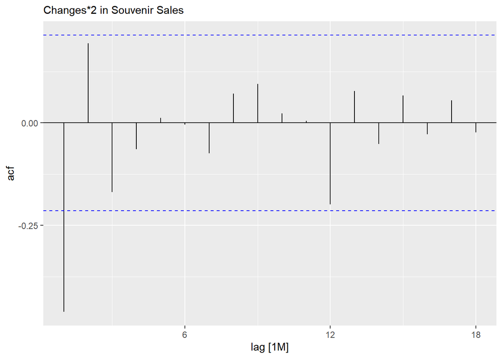

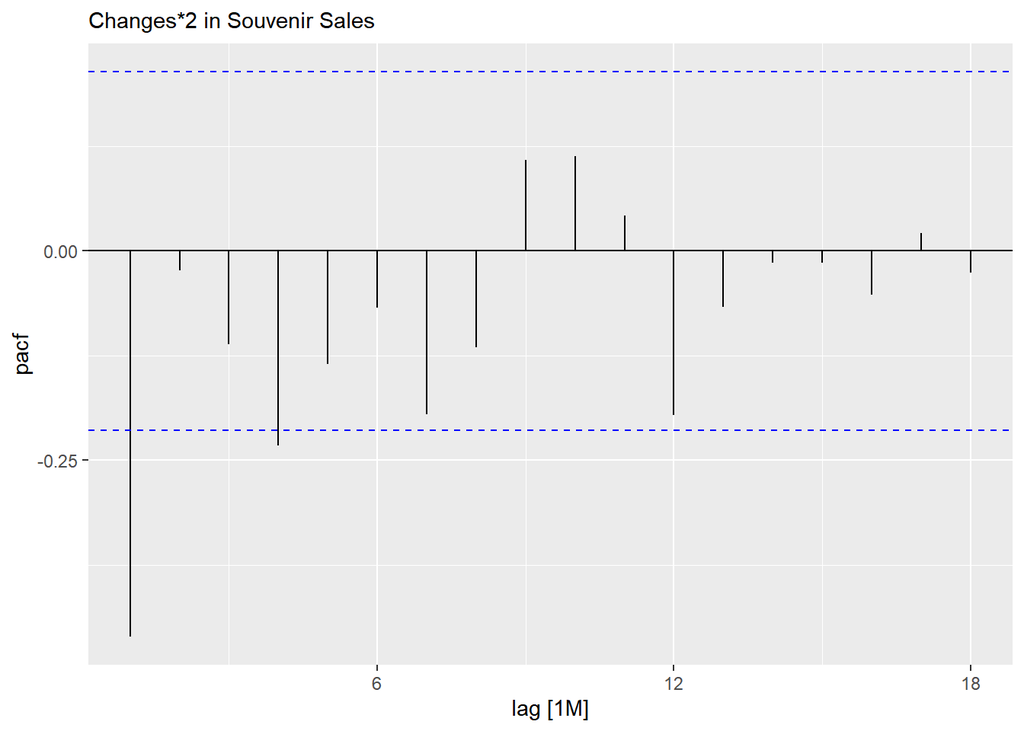

```
## # A tibble: 1 × 2
##   lb_stat    lb_pvalue
##     <dbl>        <dbl>
## 1    53.7 0.0000000559
```

### 9.5

*9.5 For your retail data (from Exercise 8 in Section 2.10), find the appropriate order of differencing (after transformation if necessary) to obtain stationary data.*

For my series we need at least 2 differences.Even after a seasonal (12 month) difference, there still apeeared to be patterning in the acf.

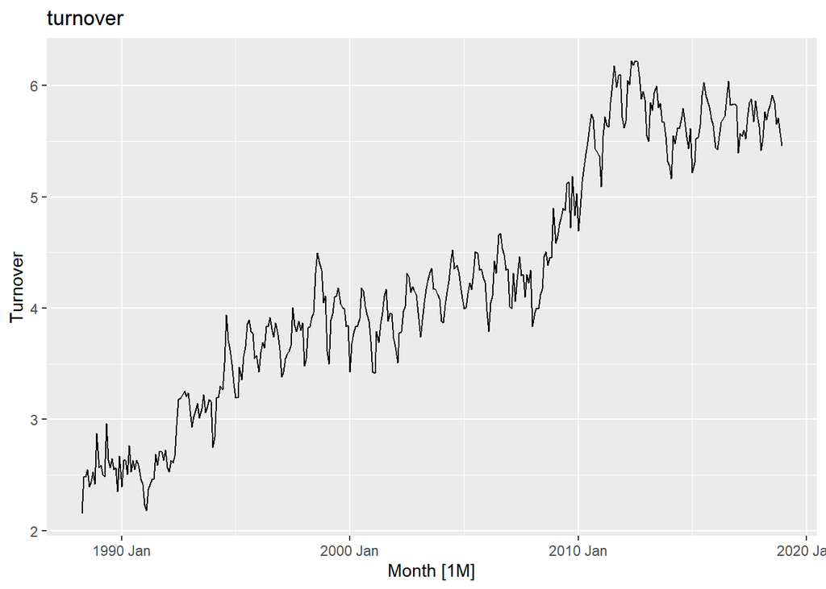

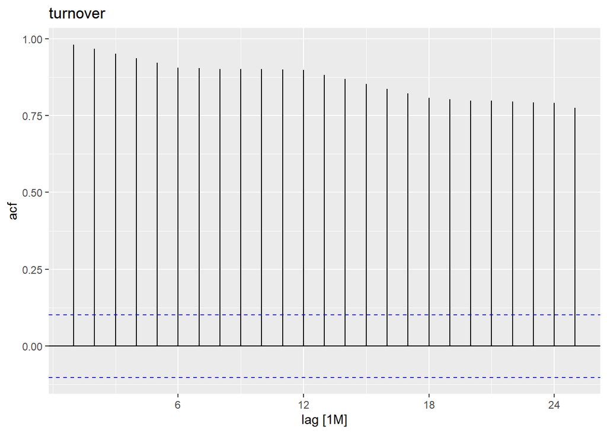

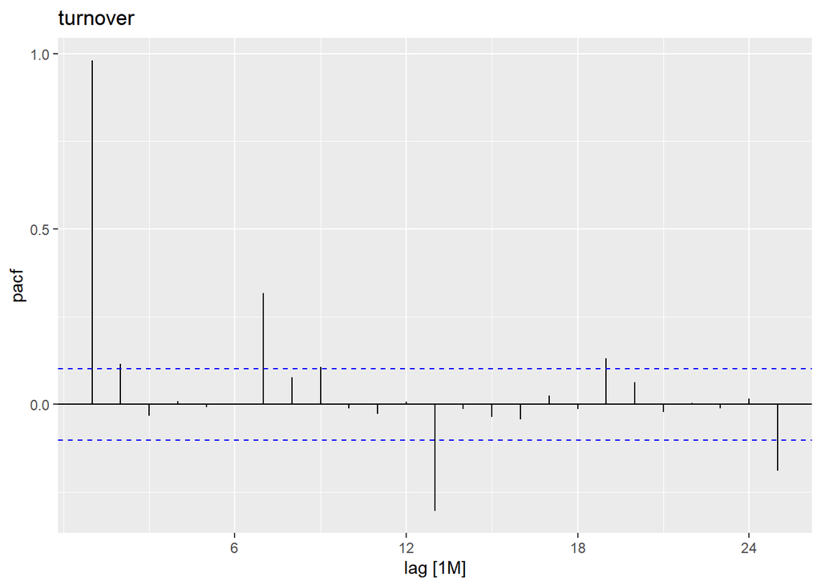

```
## [1] 1
```

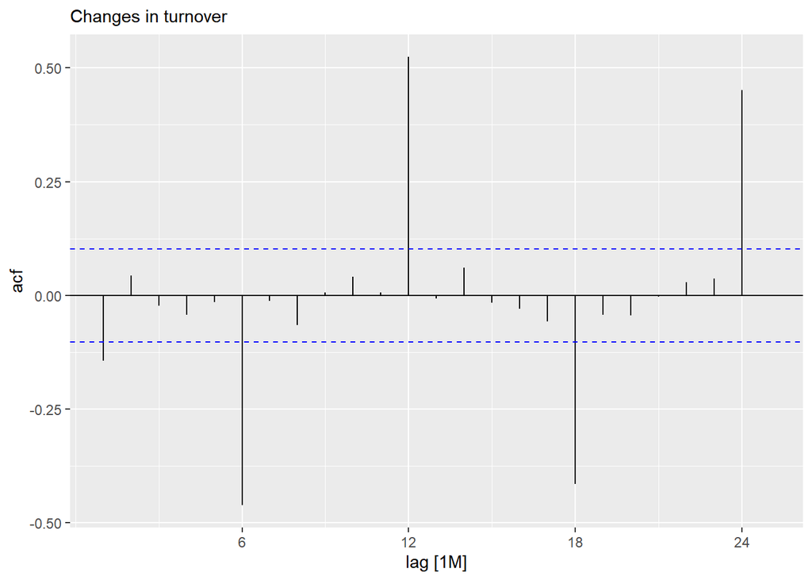

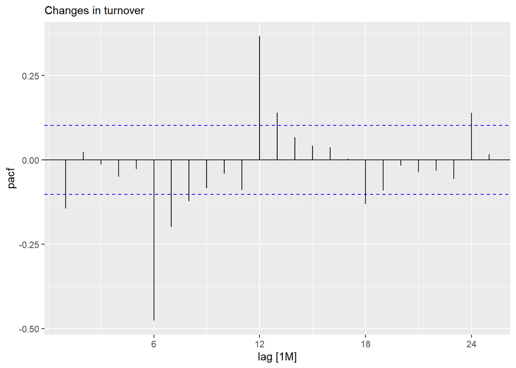

```
## # A tibble: 1 × 2
##   lb_stat lb_pvalue
##     <dbl>     <dbl>
## 1    91.7  2.44e-15
```

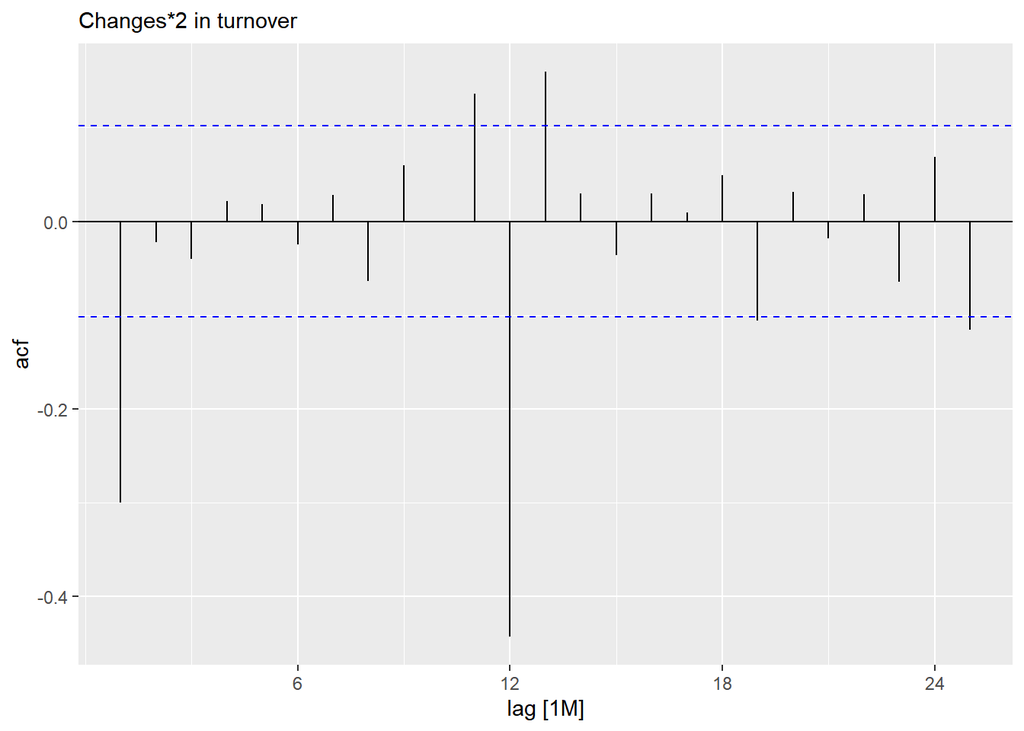

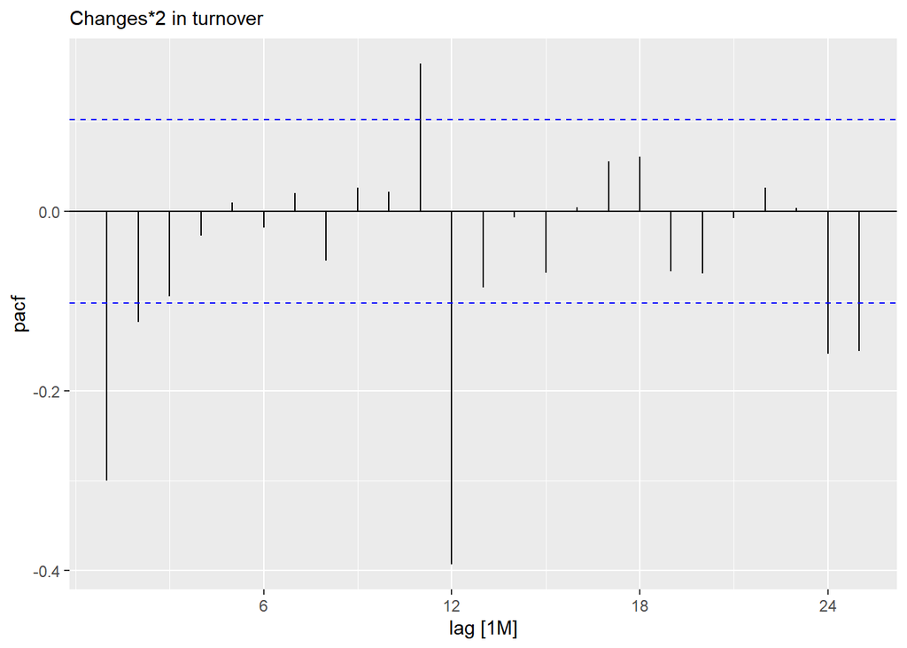

```
## # A tibble: 1 × 2
##   lb_stat lb_pvalue
##     <dbl>     <dbl>
## 1    36.5 0.0000682
```

### 9.6

*9.6 Simulate and plot some data from simple ARIMA models.*

*9.6b Produce a time plot for the series. How does the plot change?*

The plot becomes denser with decreasing levels of phi.

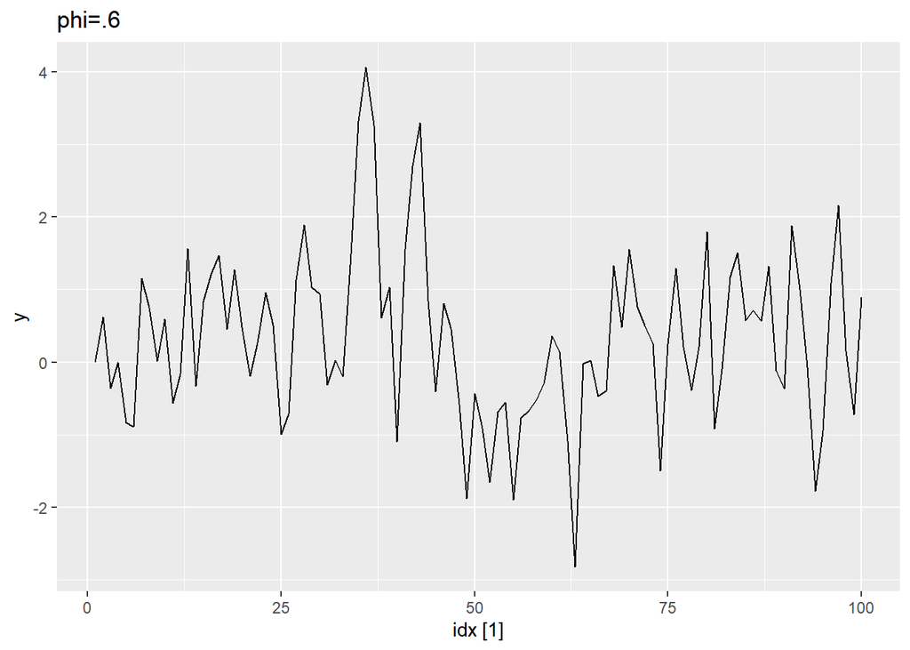

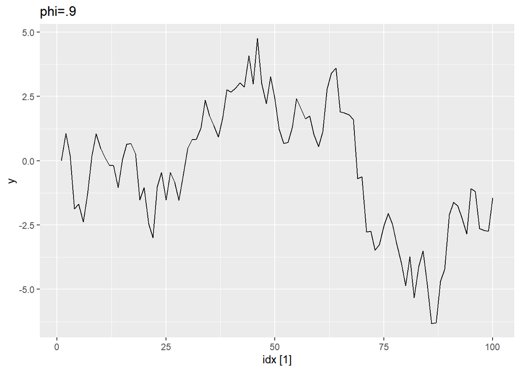

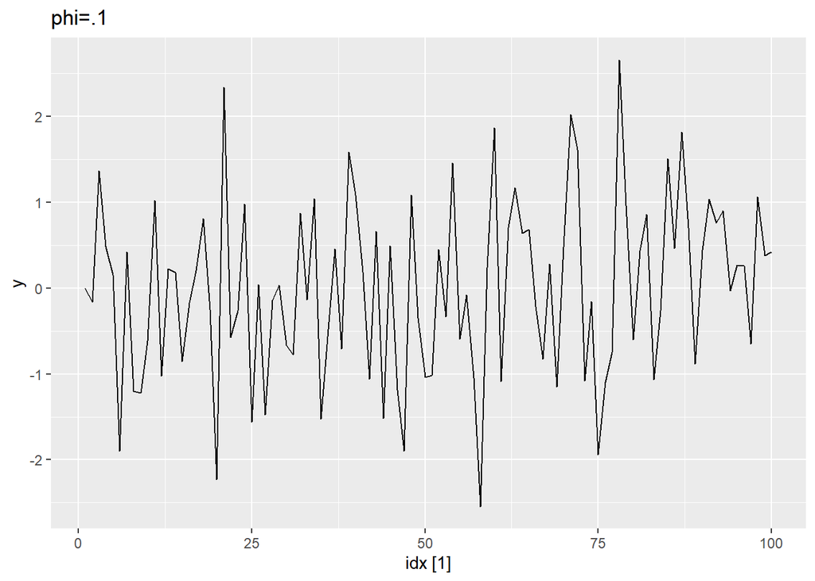

*9.6c Write your own code to generate data from an MA(1) model*